# Projekat iz obrade prirodnih jezika.

# Zajednička analiza

U zajedničkoj analizi se pripadnost kategoriji i sentiment predviđaju odjednom tako što se definiše skup klasa `None, Positive, Negative, Neutral`. Obzirom da je ovo zadatak višeklasne klasifikacije autori smatraju da je ovakav tip zadatka podskup tipa zadatka predviđanja sentimenta iz odvojene analize. Zato za zajedničku analizu radi uštede vremena i konciznosti rada nisu isprobane sve konfiguracije već samo one koje su na odvojenoj analizi davale najbolje rezultate.

Poređenje zajedničke i odvojene analize je vršeno tako što se na celom skupu podataka porede rezultati predikcije iz dva koraka i predikcije iz jednog koraka sa odgovarajućom konverzijom labela:

- Ako podatak na predikciji aspekta nije dobro klasifikovan njemu se dodeljuje invalidna vrednost klase (autori biraju -1)
- Ako podatak na predikciji aspekta jeste dobro klasifikovan i klasifikovan je tako da ne pripada aspektoj kategoriji - ta kategorija se čuva u konačnim labelama.
- Ako podatak na predikciji aspekta jeste dobro klasifikovan i klasifikovan je tako da pripada aspektnoj kategoriji - obeležja za te primere se šalju na predikciju sentimenta
- Dobijene predikcije iz sentiment modela se čuvaju u konačnim labelama

**Napomena**: Poređenje se vrši na celom skupu podataka jer autori smatraju da je tako najravnopravnije jer su zbog stratifikacije različite podele podataka koriščene u zajedničkoj i odvojenoj analizi.

## Naivni Bajes

Konfiguracija koja je koriščena je `lowercase, stop-words, stem`. Algoritam kros-validacije, obučavanja i testiranja je identičan onom koji se koristi u drugoj fazi odvojene analize.

U nastavku su prikazani rezultati kros-validacije, obučavanja i evaluacije

### Optimalni hiperparametri

|  | lowercase, stop-words, stem |
| --- | --- |
| Gluma | 0.2223 |
| Opsti utisak film | 0.1112 |
| Opsti utisak komentar | 0.1112 |

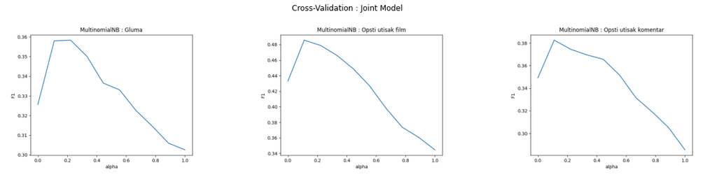

##### F1 metrika tokom kros-validacije (usrednjena na svim strukovima)

|  | lowercase, stop-words, stem |
| --- | --- |
| Gluma | 0.358309 |
| Opsti utisak film | 0.485660 |
| Opsti utisak komentar | 0.382553 |

##### F1 metrika na trening skupu

|  | lowercase, stop-words, stem |
| --- | --- |
| Gluma | 0.920869 |
| Opsti utisak film | 0.923496 |
| Opsti utisak komentar | 0.900294 |

Vidimo da se metrike u kros-validaciji i treningu znatno razlikuju, što nam ukazuje da je opet došlo do preobučavanja

### Testiranje (Evaluacija)

U nastavku su tabelarno prikazani F1 skorovi na test skupu kao i matrice konfuzije.

|  | lowercase, stop-words, stem |
| --- | --- |
| Gluma | 0.339891 |
| Opsti utisak film | 0.459605 |
| Opsti utisak komentar | 0.401090 |

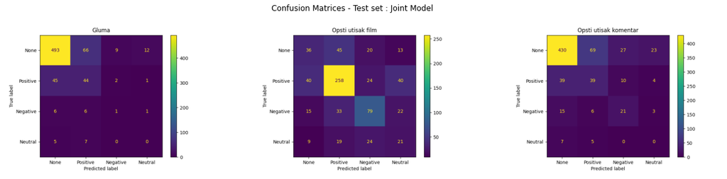

Primećujemo da jeste došlo do preobučavanja kao i da performanse nisu znaćajno bolje u odnosu na odvojenu analizu za ovaj model. Takođe je evidentno da model najviše grešaka pravi na neutralnom sentimentu.

### Poređenje između odvojene i zajedničke analize

U nastavku su prikazani F1 skorovi na celom skupu podataka za modele iz zajedničke i odvojene analize.

|  | One stage | Two stage |
| --- | --- | --- |
| Gluma | 0.793671 | 0.683481 |
| Opsti utisak film | 0.825736 | 0.674427 |
| Opsti utisak komentar | 0.763751 | 0.586335 |

Iz ovog rezultata deluje da je model zajedničke analize bolji od modela odvojene analize. Ali autori ipak smatraju da ovo poređenje nije sasvim verodostojno zbog toga što se trening skupovi tokom predviđanja aspekta i tokom predviđanja sentimenta ne podudaraju.

### Metoda potpornih vektora (Linearni kernel)

Konfiguracija koja je koriščena je `lowercase, tf_idf, stop-words, stem`. Algoritam kros-validacije, obučavanja i testiranja je identičan onom koji se koristi u drugoj fazi odvojene analize.

U nastavku su prikazani rezultati kros-validacije, obučavanja i evaluacije

### Optimalni hiperparametri

|  | lowercase, stop-words, stem |
| --- | --- |
| Gluma | 0.7778 |
| Opsti utisak film | 0.2223 |
| Opsti utisak komentar | 0.7778 |

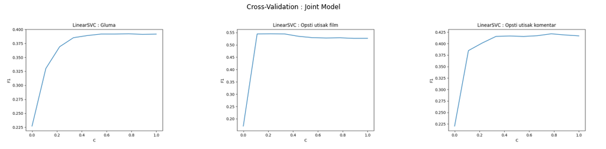

##### F1 metrika tokom kros-validacije (usrednjena na svim strukovima)

|  | lowercase, stop-words, stem |
| --- | --- |
| Gluma | 0.392129 |
| Opsti utisak film | 0.544676 |
| Opsti utisak komentar | 0.421454 |

##### F1 metrika na trening skupu

|  | lowercase, stop-words, stem |
| --- | --- |
| Gluma | 0.993103 |
| Opsti utisak film | 0.890687 |
| Opsti utisak komentar | 0.971116 |

Vidimo da se metrike u kros-validaciji i treningu znatno razlikuju, što nam ukazuje da je opet došlo do preobučavanja

### Testiranje (Evaluacija)

U nastavku su tabelarno prikazani F1 skorovi na test skupu kao i matrice konfuzije.

|  | lowercase, stop-words, stem |
| --- | --- |
| Gluma | 0.353798 |
| Opsti utisak film | 0.435987 |
| Opsti utisak komentar | 0.399386 |

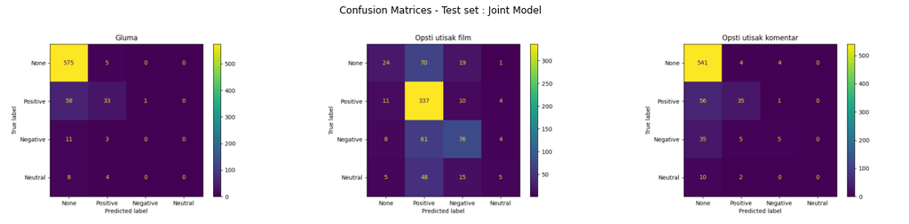

Vidimo da model potpornih vektora (sad već donekle očekivano) daje jako loše rezultate. U poređenju između zajedničke i odvojene analize za ovaj model, predviđanje aspektne kategorije je dalo jako loše rezultate. Model nije uspešno predvideo pripadnost aspektnoj kategoriji ni jedne klase, te analiza sentimenta praktično nije ni izvršena. Zbog ovoga je poređenje izostavljeno.

# Bonus

Autori projekta su rešili da probaju još neki pristup koji nije naveden u tekstu zadatka i nije učen u potpunosti na predavanjima radi proširivanja znjanja i potencijalnog boljitka u rezultatima.

Dve značajne izmene koje su autori uveli su korišćenje word-embedding metoda za ekstrakciju obeležja iz teksta kao i korišćenje dubokih neuralnih mreža kao modela mašinskog učenja.

Metode ekstrakcije obeležja koje su autori probali su:

- Word2Vec
- FastText
- Doc2Vec Pri čemu Word2Vec i FastText pretvaraju reči u embedding a Doc2Vec pretvara rečenice (dokumente u embedding). Obzirom da autori rada rade sa rečenicama kao ulazom, reprezentacije iz Word2Vec i FastText su dobijene tako što je reprezentacija za rečenicu dobijena usrednjavanjem reprezentacija reči u toj rečenici.

Autori su se ipak usredsredili na Doc2Vec način ekstrakcije obzirom da se usrednjavanjem reprezentacija može izgubiti informacija koju rečenica nosi.

Kao neuralna mreža korišćen je višeslojni perceptron. Perceptron je implementiran da ima svega 2 skrivena sloja obzirom da je za vrednost dužine vektora reprezentacije izabrana vrednost 256. Takođe je korišćen dropout kao mera regularizacije.

Kao optimizacioni algoritam je korišćena implementacija Adama sa "weight decay" mehanizmom.

Nažalost, opet rezultati nisu bili zadovoljavajući i ovaj put je to bilo zbog neadekvatnih podataka. Naime, odrađen je eksperiment gde je za svaku aspektnu kategoriju iz zajedničke analize izvršena redukcija dimenzija dobijenih obeležja na dve dimenzije zbog vizuelizacije. Korišćena je t-SNE metoda za (nelinearnu) redukciju dimenzija. Potom je izvršena vizuelizaciaj redukovanih obeležja u nadi da se primeti separabilnost između različitih klasa.

Na narednoj slici je prikazana ova vizuelizacija. Odbirci svake klase ("None", "Positive", "Negative", "Neutral") su obojeni različitom bojom.

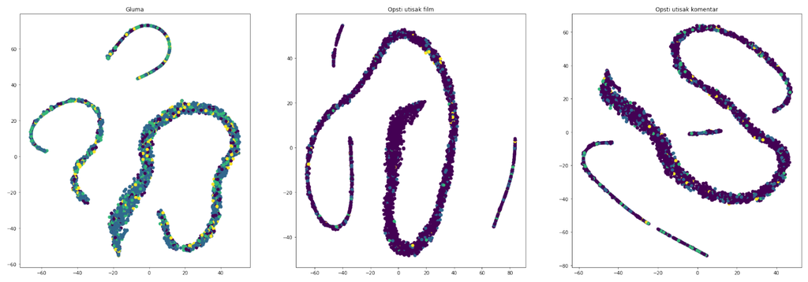

Jasno se vidi da ne postoji nikakva separabilnost. Odnosno da "embedding" metoda ne daje informativna obeležja.

Zbog ovoga autori su odlučili da preskoče prikazivanje rezultata koji su poražavajući, ali su ostavili jupyter svesku `Bonus_pristupi.ipynb` gde su prikazane implementacije i pojedine vizuelizacije iz ovih eksperimenata.

# Zaključak

Obrada prirodnih jezika (naročito Srpskog obzirom na manjak resursa) jeste izuzetno kompleksan problem. Autori ovog rada smatraju da dobijeni rezultati nisu dobri i da je potrebno uložiti dosta više vremena u prikupljanje i anotiranje podataka kao i istraživanje različitih metoda mašinskog učenja. Ipak ovaj projekat je bio veliki izazov i autori slobodno mogu reći da su puno naučili i da su zadovoljni celim procesom kako međusobne saradnje tako i saradnje sa predavačima na predmetu. Zahvaljuju se asistentu Vuku Batanoviću na predloženoj temi i obezbeđenim podacima i obećavaju da će stečeno znanje koristiti kako u daljem školovanju tako i u profesionalnoj karijeri.